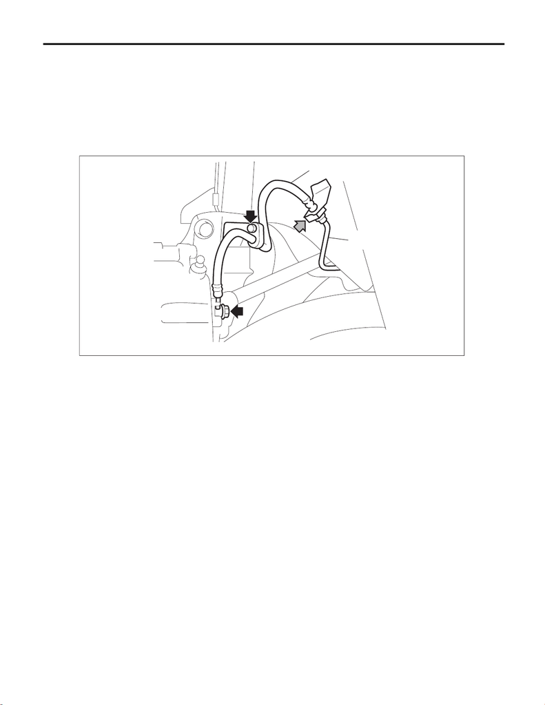

Brake Hose

BRAKE

12.Brake Hose

A: REMOVAL

1. FRONT BRAKE HOSE

1) Disconnect the brake hose (a) and the brake pipe (b).

Tools used:

Flare nut wrench

2) Remove the clamp, strut mounting bolt and union bolt, and remove the front brake hose.

(a)

(b)

BR-00950

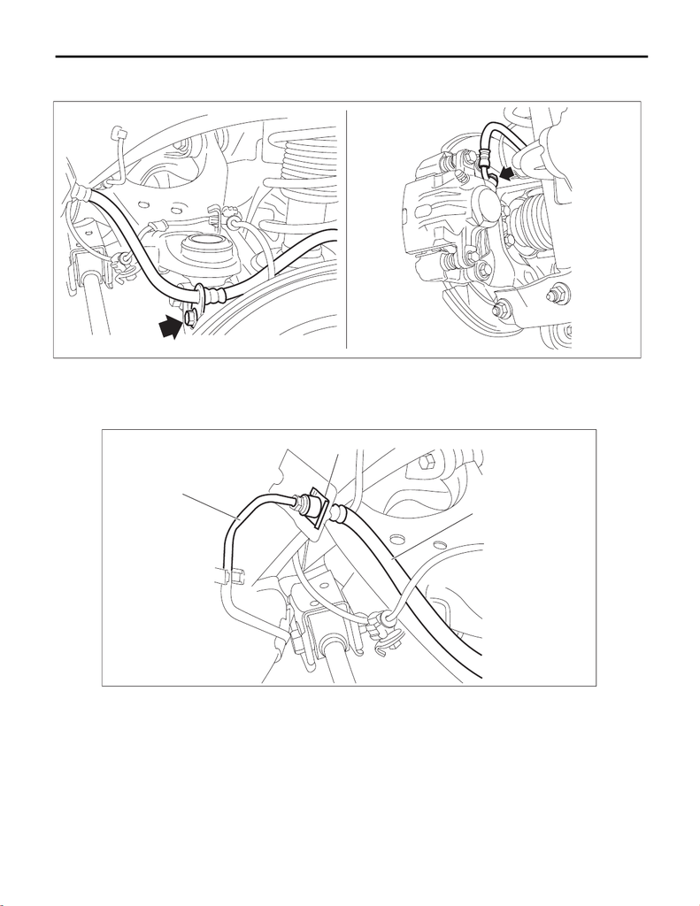

BRAKE

2. REAR BRAKE HOSE

1) Remove the brake hose bracket bolt and union bolt.

2) Disconnect the brake pipe (a).

Tools used:

Flare nut wrench

3) Remove the brake hose clamp (b), and remove the rear brake hose (c).

BR-01003

(a)

(b)

(c)

BR-00951

[figure not shown]

BRAKE

B: INSTALLATION

1. FRONT BRAKE HOSE

1) Secure the brake hose to the brake hose mount part of strut COMPL.

Tightening torque:

Brake hose: 33 N·m (3.4 kgf-m, 24.3 ft-lb)

2) Connect the brake hose to the caliper body assembly using a new gasket.

Tightening torque:

Union bolt: 26 N·m (2.7 kgf-m, 19.2 ft-lb)

3) Position the disc rotor in straight position and route the brake hose through the hole in the bracket on the

wheel apron side.

CAUTION:

Do not twist the brake hose.

4) Connect the brake pipe and the hose, then temporarily tighten the flare nut.

5) Secure the brake hose to wheel apron bracket with clamp.

6) Tighten the flare nut to the specified torque.

Tightening torque:

15 N·m (1.5 kgf-m, 11.1 ft-lb)

7) Bleed air from the brake system. <Ref. to BR-65, PROCEDURE, Air Bleeding.>

2. REAR BRAKE HOSE

1) Route the brake hose through the hole of bracket, and lightly tighten the flare nut to connect brake pipe.

2) Insert the clamp to secure brake hose.

Tightening torque:

Brake hose bracket: 33 N·m (3.4 kgf-m, 24.3 ft-lb)

3) Install the brake hose to rear caliper body using a new gasket.

Tightening torque:

Union bolt: 26 N·m (2.7 kgf-m, 19.2 ft-lb)

4) Tighten the flare nut to the specified torque.

Tightening torque:

Brake pipe flare nut: 15 N·m (1.5 kgf-m, 11.1 ft-lb)

5) Bleed air from the brake system. <Ref. to BR-65, PROCEDURE, Air Bleeding.>

C: INSPECTION

Check the hose for crack, interference with other parts, damage, and fluid leakage on connecting sections.

If any faulty is found, repair or replace the relevant part.